# Hyperspectral image analysis for spectral feature extraction

### Importing Libraries

```python
import scipy.signal
from scipy.stats import linregress
import numpy as np
import os
from sympy.solvers.solveset import solveset
import spectral.io.envi as envi
import pandas as pd
import math
from sympy import Symbol
from spectral import imshow
import matplotlib.pyplot as plt
from spectral import *
import seaborn as sns
import warnings
import csv
warnings.filterwarnings('ignore')
```

### Importing File into the program.

For this case, sample no. 86 is used. This sample is F4TCNQ doped P3HT, where a polymer solution was spincoated on a quartz substrate and dipped into a 10 mM F4TCNQ solution.

The below funciton read_bil() takes the filename and extension of the sample for its parameter.

Using imshow(), the imported array is shown as an RGB image.

```
File "86.bil" has been imported.
```

```
ImageView object:
  Display bands       :  (30, 259, 10)
  Interpolation       :  <default>
  RGB data limits     :
    R: [0.0, 3.6940999031066895]
    G: [0.13609999418258667, 2.1974000930786133]
    B: [0.0, 1.8071999549865723]
```

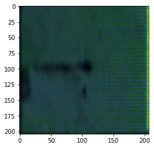

```python
def read_bil(file):
    hdr = file+'.hdr'
    data_ref = envi.open(hdr,file)
    data_nparr = np.array(data_ref.load())
    print('File "' + file + '" has been imported.')
    return data_nparr

data_arr = read_bil('86.bil')
imshow(data_arr,(30,259,10))
```

### Choosing a Region of Interest (ROI)

The next step was to choosse a region of interest on the sample. This can be denoted by selecting an origin on the 2-D array by assigning co-ordinates to x and y.

The w parameter sets the horizontal limit. w extends out to the right of the origin. The h parameter sets the vertical limit of the region. h extends downwards from the origin.

line and intensity are visual parameters and only serve purpose to make it easier to view the selected region

```
ImageView object:
  Display bands       :  [0, 150.0, 299]
  Interpolation       :  <default>
  RGB data limits     :
    R: [0.0, 2.579699993133545]
    G: [0.0066999997943639755, 4.183599948883057]
    B: [0.0, 2.200000047683716]
```

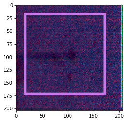

```python
def extract_roi(arr, x, y, w, h, intensity, line):
    roi = arr[y:y+h, x:x+w, :]

    bounding_box = arr
    bounding_box[y-line:y, x-line:x+w+line, :] = intensity
    bounding_box[y:y+h, x-line:x, :] = intensity
    bounding_box[y+h:y+h+line, x-line:x+w+line, :] = intensity
    bounding_box[y:y+h, x+w:x+w+line, :] = intensity

    return (roi, bounding_box)

origin = 20
side = 150
line = 5
intensity = 2
bound_box = None


roi, bound_box = extract_roi(data_arr,origin,origin,side,side,intensity, line)
imshow (bound_box)
```

### Plotting the mean absorabance of a Region of Interest

plotROI() is a function used to plot the mean absorabance spectrum within the region of interest.

It takes the mean transmittance value accross every pixel in the region of interest, and this transmittance value is converted to a measure of absorbance.

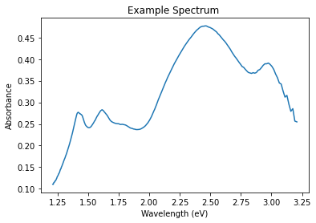

```python
def plotROI(roi,eV,title):
    #fig2, ax2 = plt.subplots(figsize = (10,7))
    intensity = []
    intensity_corrected =[]
    for b in range(roi.shape[2]):
        intensity.append(np.mean(roi[:, :,b]))
    absorbance = [ - math.log(y,10) for y in intensity]
    plt.plot(eV,absorbance)
    plt.title(title)
    plt.xlabel('Wavelength (eV)')
    plt.ylabel('Absorbance')

bands = np.genfromtxt("bands.csv", delimiter=',')
bands = bands[0][:]
eV = 1239.8/bands
title = 'Example Spectrum '
plotROI(roi,eV,title)
```

### Plotting the absorbance spectrum of individual pixels

Conversely, pixel_spectrum() takes a set of co-ordinates and the region of interest array as input and returns the absorbance spectrum at a specific set of co-ordinates.

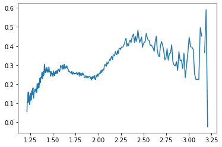

```python
def pixel_spectrum(x,y,arr):
    pixel_x = x
    pixel_y = y
    pixel = arr[pixel_y, pixel_x,:]
    pixel_abs = - np.log10(pixel)
    pixel_abs = pixel_abs
    return pixel_abs

individual = pixel_spectrum(40,100,roi)

plt.plot(eV, individual)
```

### Calculating the Average Free Exciton Width

The average free exciton width of the sample can be estimated from the absorption ratio between A(0-0) and A(0-1).

The ratio parameter is the ratio of the absorbance at 1.5 eV and the absorbance at 2.3 eV.

```python
def exciton_width(ratio):
    w = (1 - math.sqrt(ratio))/((0.405555*math.sqrt(ratio))+1.3333333)
    return w


ratio = individual[210]/individual[54]
ew = exciton_width(ratio)
print(ew)
```

```
0.1440337572869357
```

### Identifying the peaks in the absorbance spectrum

Using peaks() the peak value of the absorbance spectra at a pixel is extracted using the SciPy find_peaks function.

The absorbance and the corresponding wavelength are stored to y and x, respectively, for visualisation.

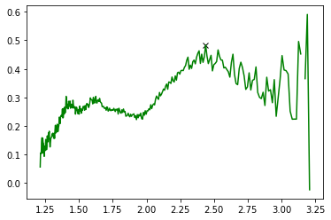

```python
def peaks(pixel_abs,eV):
    x = np.stack((eV[14:],pixel_abs[14:]),1)
    x=x.T
    peaks , _ = scipy.signal.find_peaks(x[1],distance = 300)
    peakabs = x[1][peaks]
    peakindex = np.where(x[1] == peakabs)
    peakenergy =x[0][peakindex[0]]
    return peakabs,peakenergy

y,x = peaks(individual,eV)

plt.plot(x,y,'x',color = 'black')
plt.plot(eV,individual,color= 'green')
```

### Bringing together all functions to create characteristic heatmaps

These values are stored as 2D arrays which are then plotted as heatmaps using the library, seaborn.

```python
def peakabs(rois,eV,el):
    abslist = []
    evlist =[]
    energyratio=[]
    abs = np.zeros((roi.shape[0],roi.shape[1]))
    energy = np.zeros((roi.shape[0],roi.shape[1]))
    ratio = np.zeros((roi.shape[0],roi.shape[1]))

    for x in range(roi.shape[0]):
        for y in range(roi.shape[1]):
            spectra = pixel_spectrum(x,y,roi)
            ratio[x][y] = spectra[el]/spectra[33]
            peakabs,peakev = peaks(spectra,eV)
            peakabs[peakabs>10000000] =0
            peakabs[peakabs>1] = np.mean(peakabs)
            abs[x][y]=peakabs.max()
            energy[x][y]=peakev.max()
        abslist.append(abs)
        evlist.append(energy)
        energyratio.append(ratio)
    return abslist, evlist, energyratio

absmap, evmap, ratiomap = peakabs(roi,eV,210)
```

```python
#heatmap of peak absorbance and corresponsing and ratio energy in image
def plotheatmap(abs,eV,energyratio,figtitle, title):

    fig,(ax1,ax2,ax3) = plt.subplots(1,3,figsize=(20,5))
    plt.suptitle(figtitle)
    sns.heatmap(abs[0],cmap = "Wistia",yticklabels=False,xticklabels=False, ax = ax1,vmin = 0, vmax = 0.5, cbar = True)
    ax1.set_title("Peak absorbance ")
    sns.heatmap(eV[0],cmap= 'cool',yticklabels=False,xticklabels=False,ax = ax2, vmin =2.0 , vmax =3.3,cbar = True)
    ax2.set_title("Correspondin Wavelength ")
    sns.heatmap(energyratio[0],cmap= 'YlGnBu',yticklabels=False,xticklabels=False, ax = ax3, vmin = 0, vmax = 1,cbar = True)
    ax3.set_title(title)
    plt.show()

plotheatmap(absmap,evmap,ratiomap,'Characterisation heatmaps','Exciton width ratio')
```

[output not shown]